# L1: Introduction

Bogdan G. Popescu

bogdan.popescu@johncabot.edu

John Cabot University

# Introduction

## Major topics

- Elementary programming techniques (e.g. loops, conditional statements, functions)
- Writing reusable, interpretable code
- Problem-solving - debugging programs for errors
- Obtaining, importing, and munging data from a variety of sources
- Performing statistical analysis
- Visualizing information
- Creating interactive reports
- Generating reproducible research

```r
print("Hello world!")
```

```
[1] "Hello world!"
```

```r
# load packages
library(tidyverse)
library(palmerpenguins)
library(broom)
library(kableExtra)
```

```r
# load packages
library(tidyverse)
library(palmerpenguins)
library(broom)
library(kableExtra)

#Setting path
setwd("/Users/bgpopescu/Library/CloudStorage/Dropbox/john_cabot/teaching/big_data/week1/data/")
life_expectancy <- read.csv(file = './life-expectancy.csv')
urbanization <- read.csv(file = './share-of-population-urban.csv')
```

```r
# load packages
library(tidyverse)
library(palmerpenguins)
library(broom)
library(kableExtra)

#Setting path
setwd("/Users/bgpopescu/Library/CloudStorage/Dropbox/john_cabot/teaching/big_data/week1/data/")
life_expectancy <- read.csv(file = './life-expectancy.csv')
urbanization <- read.csv(file = './share-of-population-urban.csv')

#Calculating averages
life_expectancy2<-life_expectancy%>%
  group_by(Code, Entity)%>%
  summarize(life_expectancy=mean(Life.expectancy.at.birth..historical.))

urbanization2<-urbanization%>%
  group_by(Code)%>%
  summarize(urbanization=mean(Urban.population....of.total.population.))
```

```r
# load packages
library(tidyverse)
library(palmerpenguins)
library(broom)
library(kableExtra)

#Setting path
setwd("/Users/bgpopescu/Library/CloudStorage/Dropbox/john_cabot/teaching/big_data/week1/data/")
life_expectancy <- read.csv(file = './life-expectancy.csv')
urbanization <- read.csv(file = './share-of-population-urban.csv')

#Calculating averages
life_expectancy2<-life_expectancy%>%
  group_by(Code, Entity)%>%
  summarize(life_expectancy=mean(Life.expectancy.at.birth..historical.))

urbanization2<-urbanization%>%
  group_by(Code)%>%
  summarize(urbanization=mean(Urban.population....of.total.population.))

#Cleaning data
weird_labels <- c("OWID_KOS", "OWID_WRL", "")
weird_countries<-subset(life_expectancy2, (Code %in% weird_labels))
```

```r
#Data Cleaning
clean_countries<-subset(life_expectancy2, !(Code %in% weird_labels))
clean_countries_urbanization<-subset(urbanization2, !(Code %in% weird_labels))

#Left Join
new_data<-left_join(clean_countries, clean_countries_urbanization, by = c("Code"="Code"))
```

```r
#Data Cleaning
clean_countries<-subset(life_expectancy2, !(Code %in% weird_labels))
clean_countries_urbanization<-subset(urbanization2, !(Code %in% weird_labels))

#Left Join
new_data<-left_join(clean_countries, clean_countries_urbanization, by = c("Code"="Code"))

# Getting rid of NAs for urbanization
new_data2<-subset(na.omit(new_data))
```

```r
# estimate and print the linear model
lm(life_expectancy ~ urbanization, data = new_data2) %>%
  tidy() %>%
  mutate(term = c("Intercept", "Urbanization")) %>%
  kable(digits = 2, col.names = c("Variable", "Estimate", "Standard Error",
                                         "T-statistic", "P-Value"))
```

| Variable | Estimate | Standard Error | T-statistic | P-Value |
| --- | --- | --- | --- | --- |
| Intercept | 49.70 | 1.08 | 45.92 | 0 |
| Urbanization | 0.23 | 0.02 | 11.82 | 0 |

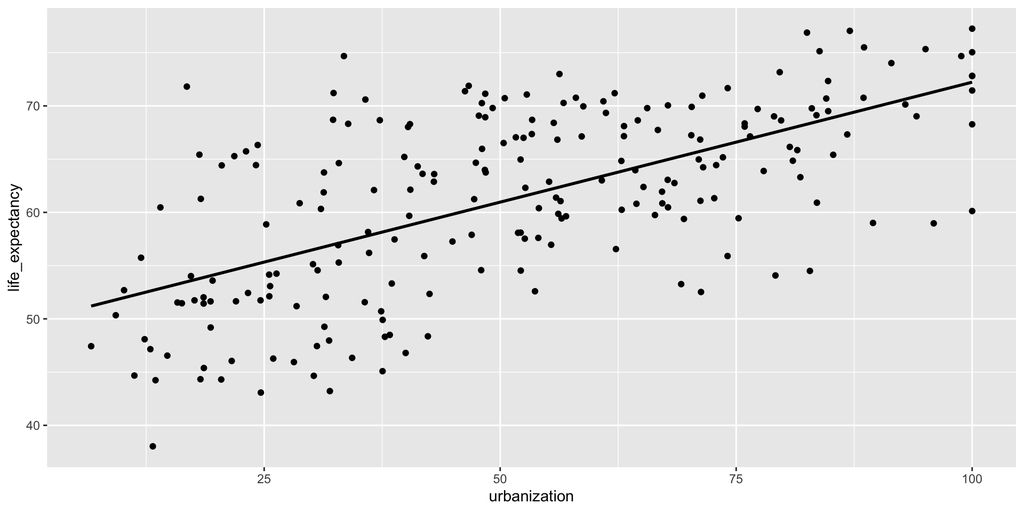

```r
# visualize the relationship

library(ggplot2)
fig1<-ggplot(new_data2, mapping = aes(x=urbanization, y=life_expectancy)) +
  geom_point()+
  geom_smooth(method = "lm", se = FALSE, color = "black", alpha = .25)
fig1
```

## Ideal student

- You feel comfortable with regression and other econometric methods in Stata or R
- You are trying to create a reproducible workflow for your analyses
- You are tryinng to write a research paper using quantitative methods
- You want to use text analysis tools
- You want to explore further topics in machine learning using R

## Solving problems on your own

- Try to solve a problem for 15 mins
- If you cannot find a solution, have another try in another 15 minutes after taking a break
- Take another break and try again
- Finally, go and aks for help

## Resources

- Google
- Stackoverflow
- ChatGBT (if available)
- Fellow students
- Me

## Collaboration

- This class is an opportunity to learn
- You have two attempts for every assignment
- The final grade for each assignment will be the average of the first and second attempts
- For the second attempt, you should meet up with your assigned team to discuss solutions
- Your peers will give you a grade for how much you contributed to the second attempt.

## Programmating Structure

- Create a folder for every lab and assignment: lab1, lab2, lab3 or assignment1, assignment2, assignment3
- Within each folder, you should have:
  1. data
  2. graphs
  3. tables (or output)
- Write a quarto report

## Automation and Reproducibility

- Automation is important
- Reduces mistakes
- It is easy to implemet in the long run
- If your data is reproducible, other people can see what you have done: other people can replicate your analyses.

## Documentation

- All your should include comments

```r
#Data Cleaning
clean_countries<-subset(life_expectancy2, !(Code %in% weird_labels))
clean_countries_urbanization<-subset(urbanization2, !(Code %in% weird_labels))
```

## Documentation

- All your should include comments

```r
#Data Cleaning
clean_countries<-subset(life_expectancy2, !(Code %in% weird_labels))
clean_countries_urbanization<-subset(urbanization2, !(Code %in% weird_labels))

#Data Cleaning
clean_countries<-subset(life_expectancy2, !(Code %in% weird_labels))
clean_countries_urbanization<-subset(urbanization2, !(Code %in% weird_labels))

#Left Join
new_data<-left_join(clean_countries, clean_countries_urbanization, by = c("Code"="Code"))
```

## Documentation

- All your should include comments

```r
#Data Cleaning
clean_countries<-subset(life_expectancy2, !(Code %in% weird_labels))
clean_countries_urbanization<-subset(urbanization2, !(Code %in% weird_labels))

#Data Cleaning
clean_countries<-subset(life_expectancy2, !(Code %in% weird_labels))
clean_countries_urbanization<-subset(urbanization2, !(Code %in% weird_labels))

#Left Join
new_data<-left_join(clean_countries, clean_countries_urbanization, by = c("Code"="Code"))
```

- Comments are the what
- Code is the how

Popescu (JCU): Lecture 1